# Test1

## Battery Life Analysis

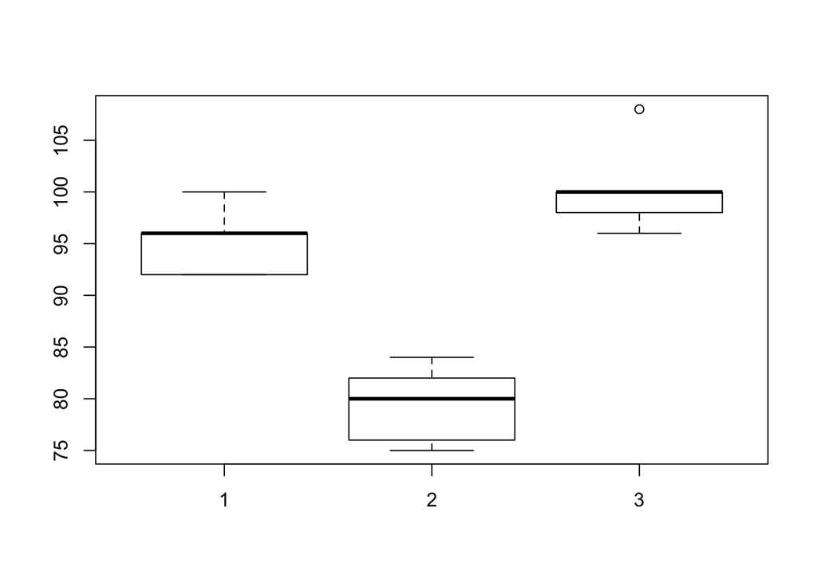

```r
boxplot(BatteryLife$FailureTime ~ BatteryLife$Material)
```

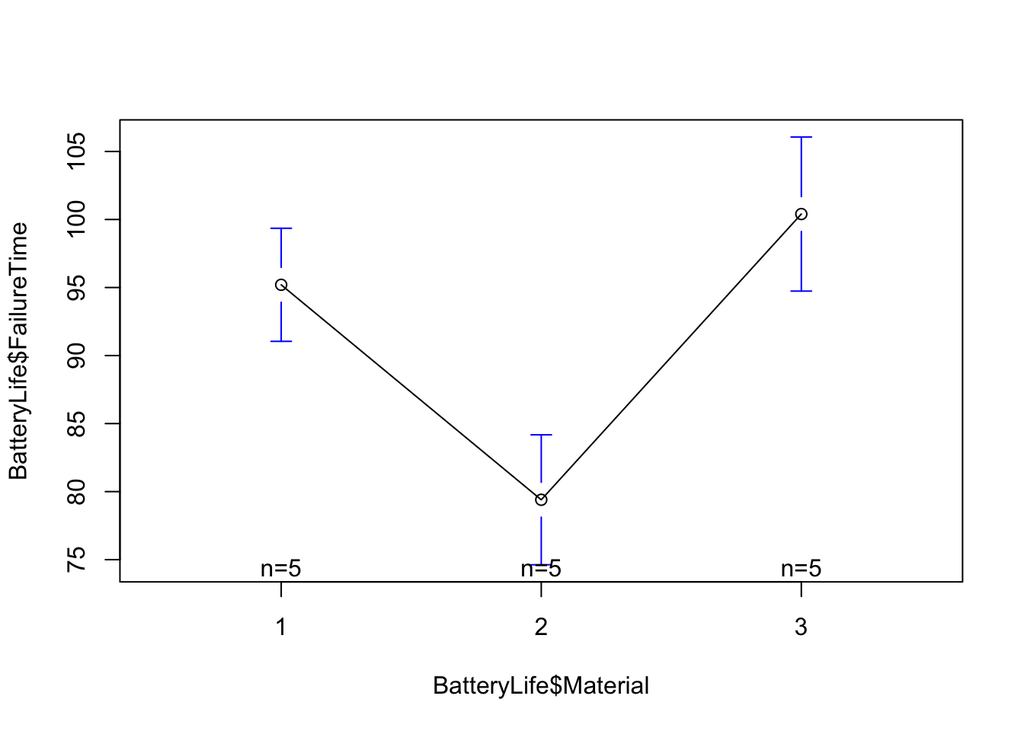

```r
plotmeans(BatteryLife$FailureTime ~ BatteryLife$Material)
```

```r
pander(favstats(BatteryLife$FailureTime ~ BatteryLife$Material))
```

| BatteryLife$Material | min | Q1 | median | Q3 | max | mean | sd | n | missing |
| --- | --- | --- | --- | --- | --- | --- | --- | --- | --- |
| 1 | 92 | 92 | 96 | 96 | 100 | 95.2 | 3.347 | 5 | 0 |
| 2 | 75 | 76 | 80 | 82 | 84 | 79.4 | 3.847 | 5 | 0 |
| 3 | 96 | 98 | 100 | 100 | 108 | 100.4 | 4.561 | 5 | 0 |

With these two graphics we are able to see that there appears to be a difference between the three groups of batteries and their life spans. This gives us reason to do our analysis, but does not necessarily tell us that anything is significant.

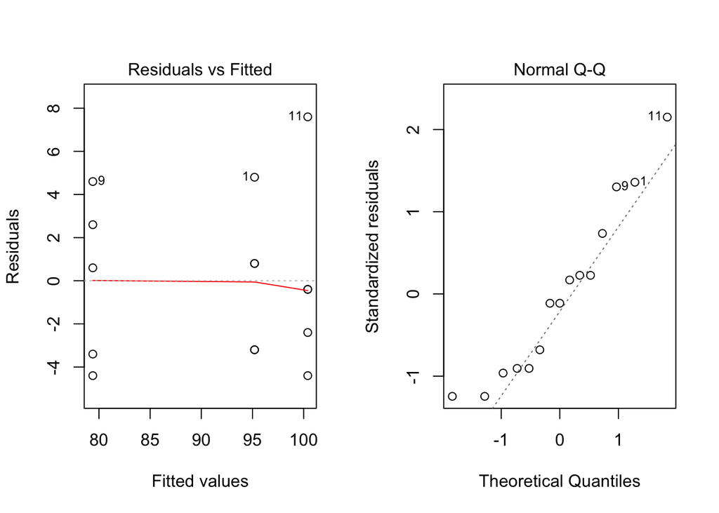

```r
par(mfrow=c(1,2))
plot(AnovaBL, which=1:2)
```

These two graphics allow us to see that it is appropriate to run the anova analysis. The residuals vs fitted graphic tells us that their seems to be some extra spread in the third group, but I would still say that we are ok to continue. The QQ-plot shows us that the data might also be a little off of what we would like to call normal. The center line does not cross directly through and it appears that the tails are coming off more than the rest of the data. Regardless, we are moving forward with the analysis.

```r
pander(summary(AnovaBL))
```

Analysis of Variance Model

|  | Df | Sum Sq | Mean Sq | F value | Pr(>F) |
| --- | --- | --- | --- | --- | --- |
| **BatteryLife$Material** | 2 | 1196 | 598.1 | 38.34 | 6.141e-06 |
| **Residuals** | 12 | 187.2 | 15.6 | NA | NA |

## Surface Finish Analysis

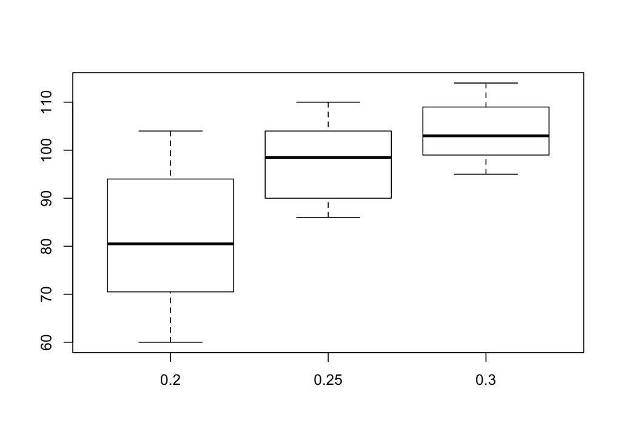

```r
boxplot(SurfaceFinish$SurfaceFinish ~ SurfaceFinish$Feedrate, id.method="y")
```

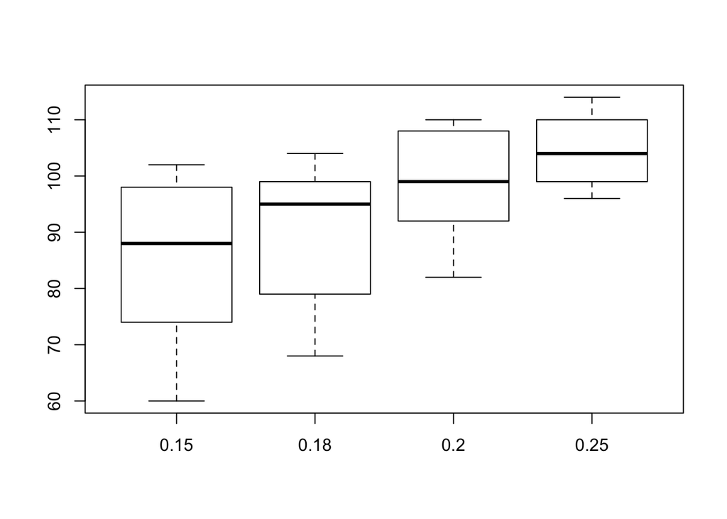

```r
boxplot(SurfaceFinish$SurfaceFinish ~ SurfaceFinish$DepthofCut, id.method="y")
```

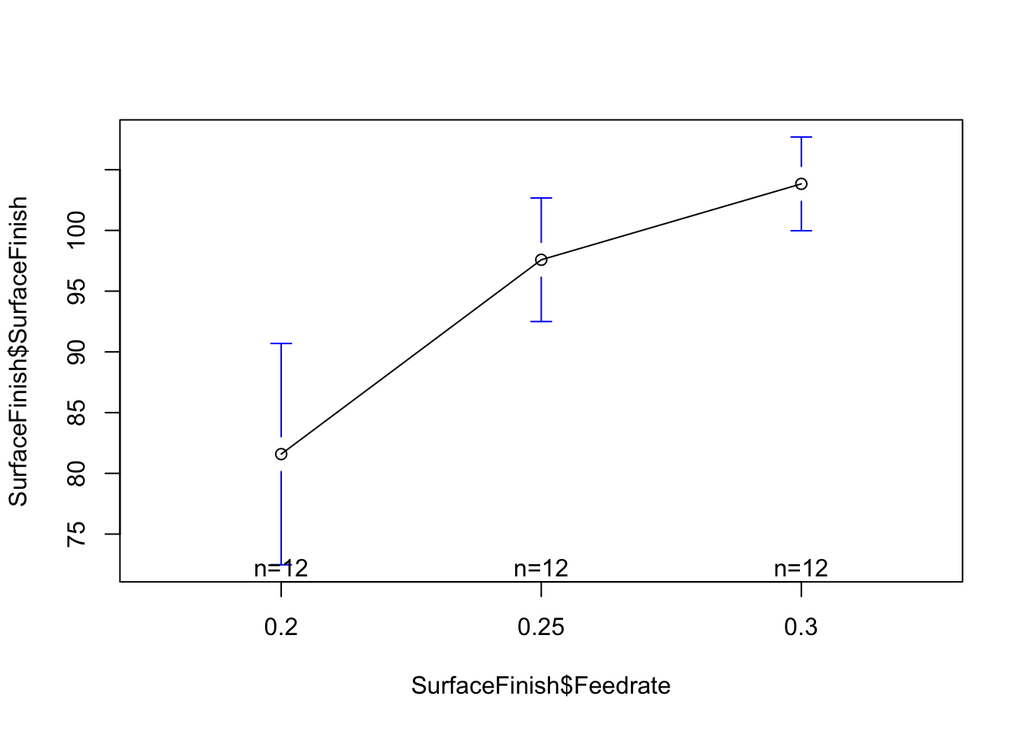

```r
plotmeans(SurfaceFinish$SurfaceFinish ~ SurfaceFinish$Feedrate, error.bars="se")
```

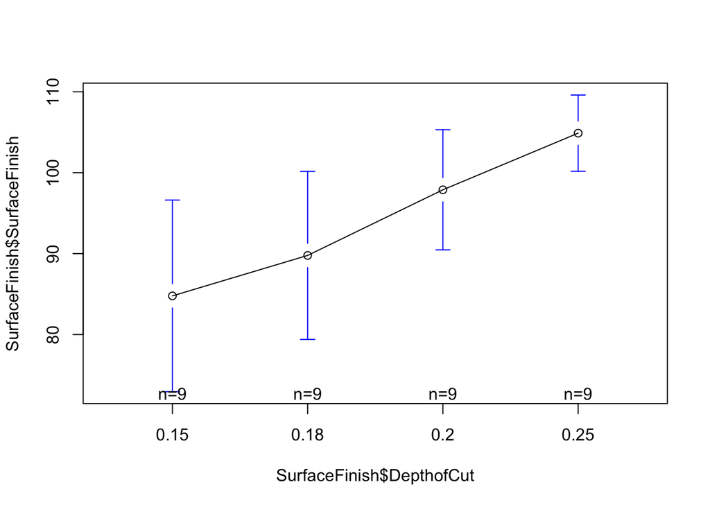

```r
plotmeans(SurfaceFinish$SurfaceFinish ~ SurfaceFinish$DepthofCut, error.bars="se")
```

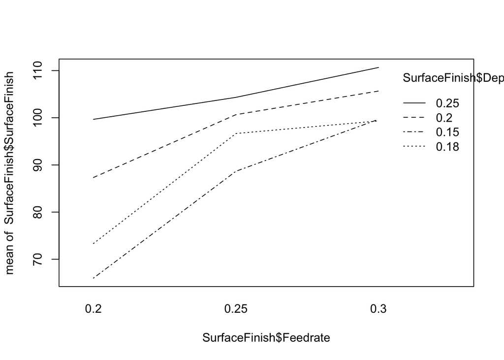

```r
interaction.plot(SurfaceFinish$Feedrate, SurfaceFinish$DepthofCut,
                 SurfaceFinish$SurfaceFinish)
```

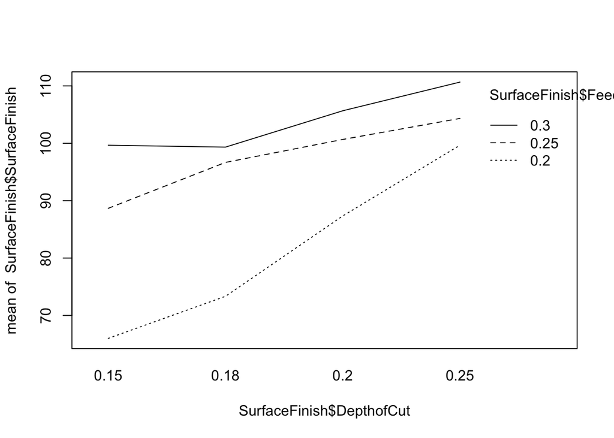

```r
interaction.plot(SurfaceFinish$DepthofCut, SurfaceFinish$Feedrate,
                 SurfaceFinish$SurfaceFinish)
```

```r
pander(favstats(SurfaceFinish$SurfaceFinish ~ SurfaceFinish$Feedrate))
```

Table continues below

| SurfaceFinish$Feedrate | min | Q1 | median | Q3 | max | mean | sd |
| --- | --- | --- | --- | --- | --- | --- | --- |
| 0.2 | 60 | 71.75 | 80.5 | 93 | 104 | 81.58 | 14.34 |
| 0.25 | 86 | 91 | 98.5 | 104 | 110 | 97.58 | 8.005 |
| 0.3 | 95 | 99 | 103 | 108.5 | 114 | 103.8 | 6.073 |

| n | missing |
| --- | --- |
| 12 | 0 |
| 12 | 0 |
| 12 | 0 |

```r
pander(favstats(SurfaceFinish$SurfaceFinish ~ SurfaceFinish$DepthofCut))
```

| SurfaceFinish$DepthofCut | min | Q1 | median | Q3 | max | mean | sd | n | missing |
| --- | --- | --- | --- | --- | --- | --- | --- | --- | --- |
| 0.15 | 60 | 74 | 88 | 98 | 102 | 84.78 | 15.41 | 9 | 0 |
| 0.18 | 68 | 79 | 95 | 99 | 104 | 89.78 | 13.51 | 9 | 0 |
| 0.2 | 82 | 92 | 99 | 108 | 110 | 97.89 | 9.662 | 9 | 0 |
| 0.25 | 96 | 99 | 104 | 110 | 114 | 104.9 | 6.133 | 9 | 0 |

In the boxplots we are able to see that with increasing both the feed rate and the depth of cut, we see an increase in the surface finish. It appears that the means of the groups are different.

By looking at the means plots we are able to confirm that the two factors do indeed show that there is a difference in the means.

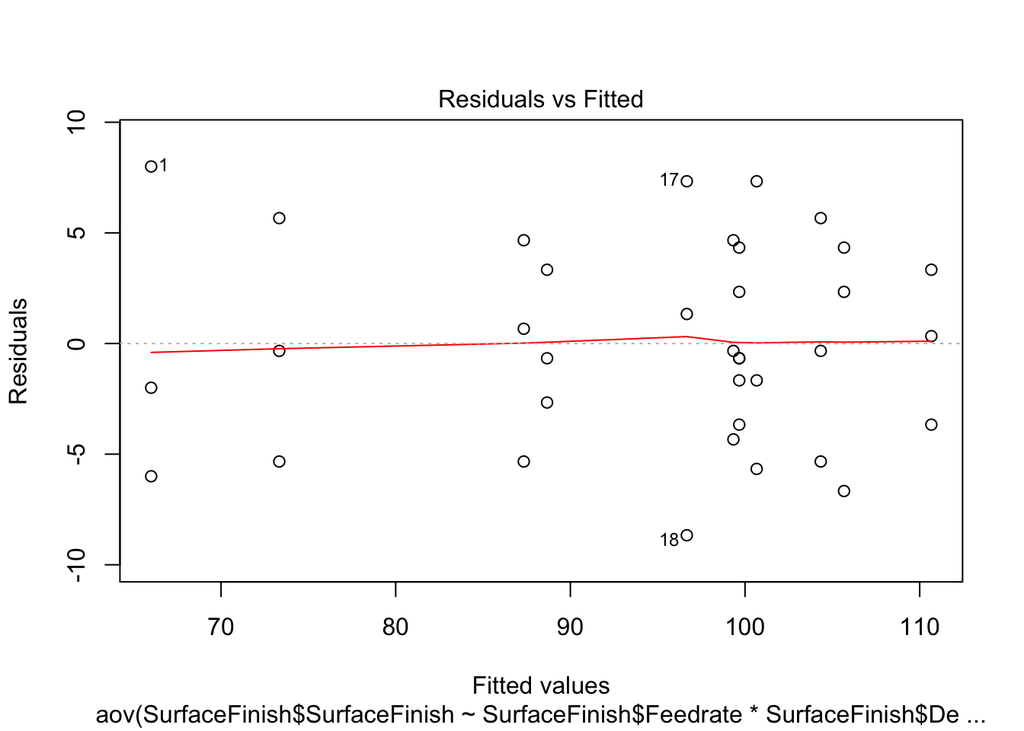

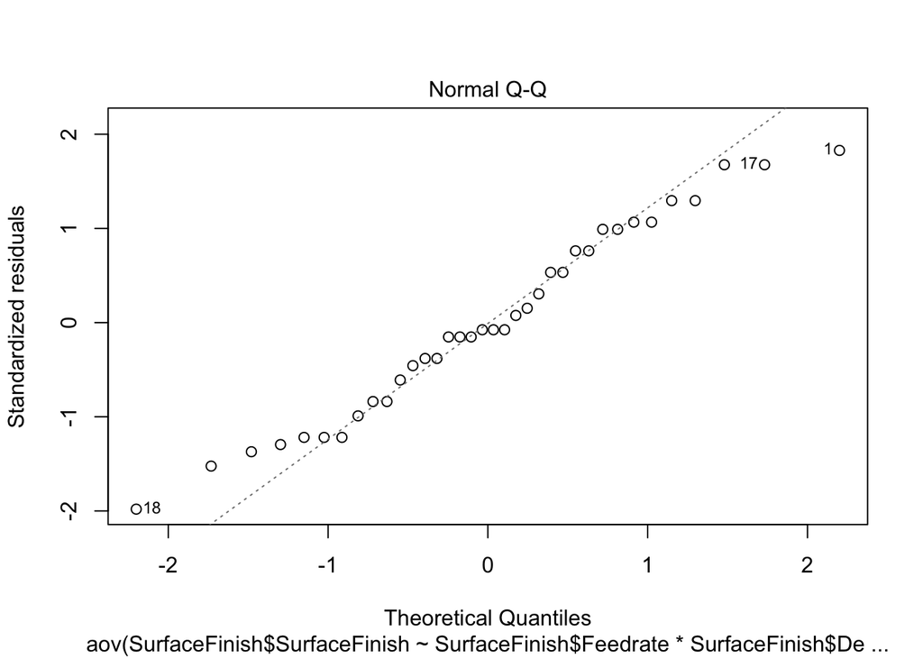

```r
plot(AnovaSF, which=1:2)
```

When checking for normality and equal variance we see that the variance is somewhat acceptable. It still appears that there are some outliers, like 1, 17 and 18, but the overall spread, beside the first group seems to be somewhat equal. The normality though continues to fail out at the ends, which leads us to believe that the data may not be as normal as we would like. The analysis will continue.

```r
pander(summary(AnovaSF))
```

Analysis of Variance Model (continued below)

|  | Df | Sum Sq | Mean Sq |
| --- | --- | --- | --- |
| **SurfaceFinish$Feedrate** | 2 | 3160 | 1580 |
| **SurfaceFinish$DepthofCut** | 3 | 2125 | 708.4 |
| **SurfaceFinish$Feedrate:SurfaceFinish$DepthofCut** | 6 | 557.1 | 92.84 |
| **Residuals** | 24 | 689.3 | 28.72 |

|  | F value | Pr(>F) |
| --- | --- | --- |
| **SurfaceFinish$Feedrate** | 55.02 | 1.086e-09 |
| **SurfaceFinish$DepthofCut** | 24.66 | 1.652e-07 |
| **SurfaceFinish$Feedrate:SurfaceFinish$DepthofCut** | 3.232 | 0.01797 |
| **Residuals** | NA | NA |

This table allows us to see what we are looking for. Is there an interaction and what would be the best way to improve the finish. The feedrate and depthofcut have similar hypotheses. They are null=that all of the groups have the same means, and alternative=at least one of the means is different. The interaction however has a null hypothesis that an interaction does not exist and an alternative hypothesis that it does. The test statistics are as follows, feedrate=55.02, depthofcut=24.66, and the interaction=3.232. Feedrate has 2 DF, depthofcut has 3 and the interaction has six, this leaves the residuals with 24. All three aspects of the test yield significant results below our level of significance 0.05. This allows us to say that we reject all null hypotheses and that there is a difference in the means between the feedrate and depthofcut and that an interaction does exist. In conclusion, by running the feedrate at .3 and the depthofcut at .25 we would be able to maximize the surface finish. This is how we are able to make sense of statistics and solve realworld situations.